# C-Band Estimation

How much could C-Band garner in revenues if it came to market? Let’s find out.

To begin, let’s start by loading all of the libraries we will need for this project.

```r
library(tidyr)
library(MASS)
library(dplyr)
library(fitdistrplus)
library(rstan)
library(car)
library(readxl)
```

Next, let’s take a look at the previous auctions in the C-band range, from 1 GHz up to about 5 GHz to see what the distributions look like.

```r
auction_data <- read.csv("Auction_Joins.csv", header=T) %>%
  mutate(Cost_MHz_pop = as.numeric(as.character(Cost_MHz_pop))) %>%
  filter(Cost_MHz_pop > 0)

auction_data41 <- auction_data %>% filter(AUCTION_NUMBER == "41")
auction_data53 <- auction_data %>% filter(AUCTION_NUMBER == "53")
auction_data58 <- auction_data %>% filter(AUCTION_NUMBER == "58")
auction_data66 <- auction_data %>% filter(AUCTION_NUMBER == "66")
auction_data69 <- auction_data %>% filter(AUCTION_NUMBER == "69")
auction_data71 <- auction_data %>% filter(AUCTION_NUMBER == "71")
```

All of the data has been normalized to June 2019 prices using CPI indices. How does this data fit?

```
summary statistics
------
min:  0.000226538   max:  6.55685
median:  0.09479346
mean:  0.2335032
estimated sd:  0.4023915
estimated skewness:  5.286192
estimated kurtosis:  50.42109
```

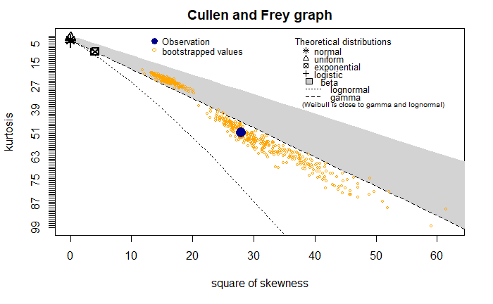

```r
descdist(auction_data$Cost_MHz_pop, discrete=FALSE, boot=500)
```

```
summary statistics
------
min:  0.02054818   max:  0.5112019
median:  0.02167761
mean:  0.03591208
estimated sd:  0.04909714
estimated skewness:  6.335113
estimated kurtosis:  52.24581
```

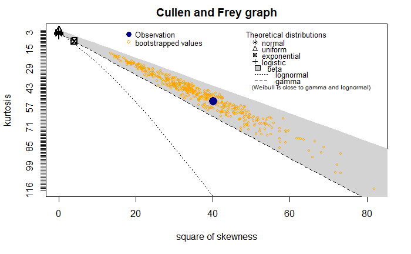

```r
descdist(auction_data41$Cost_MHz_pop, discrete=FALSE, boot=500)
```

```
summary statistics
------
min:  0.000226538   max:  0.009314287
median:  0.000647125
mean:  0.001276631
estimated sd:  0.001524143
estimated skewness:  2.726179
estimated kurtosis:  12.48186
```

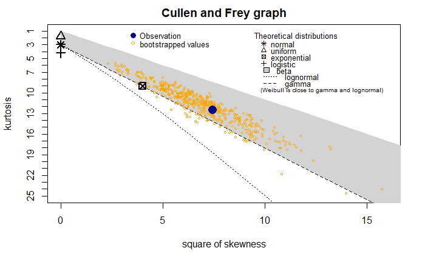

```r
descdist(auction_data53$Cost_MHz_pop, discrete=FALSE, boot=500)
```

```
summary statistics
------
min:  0.1488333   max:  6.55685
median:  0.3986387
mean:  0.7460484
estimated sd:  0.8318109
estimated skewness:  2.794087
estimated kurtosis:  14.60854
```

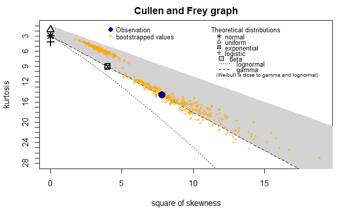

```r
descdist(auction_data58$Cost_MHz_pop, discrete=FALSE, boot=500)
```

```
summary statistics
------
min:  0.02759133   max:  2.003781
median:  0.1488242
mean:  0.2330977
estimated sd:  0.2574933
estimated skewness:  2.736954
estimated kurtosis:  13.8367
```

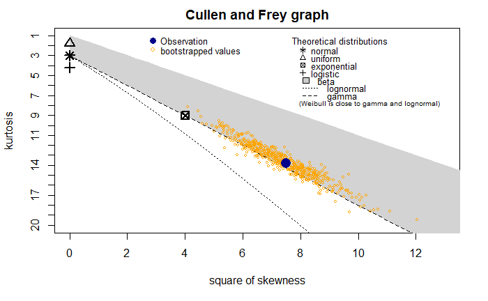

```r
descdist(auction_data66$Cost_MHz_pop, discrete=FALSE, boot=500)
```

```
summary statistics
------
min:  0.03063546   max:  0.2322091
median:  0.07403464
mean:  0.1032592
estimated sd:  0.05933441
estimated skewness:  0.754167
estimated kurtosis:  2.115828
```

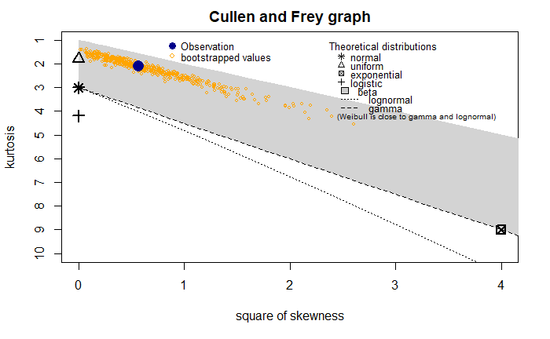

```r
descdist(auction_data69$Cost_MHz_pop, discrete=FALSE, boot=500)
```

```
summary statistics
------
min:  0.04651388   max:  1.655888
median:  0.3041648
mean:  0.3461359
estimated sd:  0.3694892
estimated skewness:  2.356229
estimated kurtosis:  9.020637
```

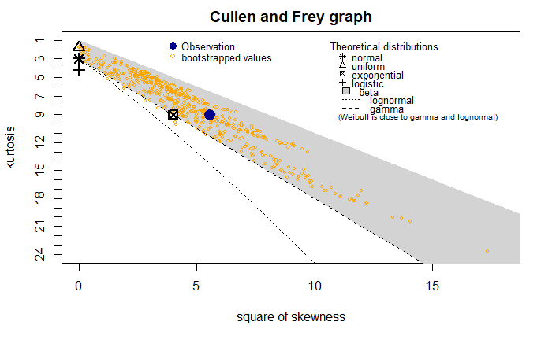

```r
descdist(auction_data71$Cost_MHz_pop, discrete=FALSE, boot=500)
```

So it seems the best distribution here is the Gamma distribution. So let’s fit the data we have on the C-Band auctions around the world and fit it to a Gamma distribution.

```r
c_band_auctions <- read_excel("5G_spectrum_database.xlsx", sheet = 2)
fp <- fitdist(c_band_auctions$fee_per_mhz_pop_june2019, "gamma")
```

```
NaNs producedNaNs produced
```

```r
summary(fp)
```

```
Fitting of the distribution ' gamma ' by maximum likelihood
Parameters :
```

|  | estimate | Std. Error |
| --- | --- | --- |
| shape | 1.040088 | 0.2548756 |
| rate | 5.150726 | 1.6044289 |

```
Loglikelihood:  15.60839   AIC:  -27.21678   BIC:  -24.70059
Correlation matrix:
          shape      rate
shape 1.0000000 0.7866944
rate  0.7866944 1.0000000
```

```r
quantile(fp, probs=c(0.05, 0.95))
```

```
Estimated quantiles for each specified probability (non-censored data)
```

|  | p=0.05 | p=0.95 |
| --- | --- | --- |
| estimate | 0.01140201 | 0.596599 |